# Joseph M. Razo, M.S.

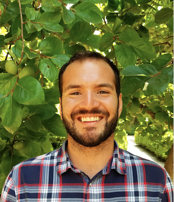

# About Me

Download my Resume

Download my full CV

My name is Joe Razo, a data scientist based in San Jose CA. My formal education was in clinical psychology where I studied ways to integrate machine learning techniques into health care systems to improve program outcomes. My dissertation (defended July 2021) focused on comparing statistical inference and GLM to statistical learning and associated learning-based algorithms to improve predictive accuracy, using the SAMHSA TEDs dataset. Along with this project, I engage in program evaluation with LifeMoves using quantitative insights is provide insights and make recommendations to decision makers regarding program development and effectiveness. I also engage in some freelance data work, with real estate data where I use deep learning networks to provide market analysis to key stakeholders.

I am a 6-year U.S. Navy veteran, where I spent 4 years stationed in Japan and traveling up and down the western pacific. I enjoy learning about different cultures and trying new foods. In my free time I like to spend time with my family and go on hikes with my dog Nala. During the winter months you can find me on the slopes in Tahoe, and on the golf courses in the spring and summer.

# Education

[Professional Data Scientist](https://www.datacamp.com/certificate/DS0010986179024) | DataCamp | February 2022  
Masters of Science in Clinical Psychology | Palo Alto University | June 2020  
Bachelor’s of Arts in Psychology | UC Irvine | June 2015

# Selected Projects

[Machine Learning with mlr3verse](https://jrazo7063.github.io/mlr3.html)

[Statistical Learning to Model Discreet Outcomes: Application for the Substance Use Treatment Field](https://jrazo7063.github.io/DissCode.html)

[Introduction to Count Distribution Analysis](https://youtu.be/4rVyLQeVDI4)

[Data Cleaning for Psychology Graduate Students](https://jrazo7063.github.io/Data-Cleaning.html)

[Introduction to ggplot2 for Psychology Graduate Students](https://youtu.be/4hu7_zcG83Q)